# Lab Assignment Two: Exploring Image Data

###### Group Members: Yifu Zhang, Yue Li, Weiyi Zhao, Siwei Wang

###### Date: Sep. 18, 2018

## 1.Businesss Understanding

### 1.1 Introduction

Although many people choose to make payment by card or electronic money, coins still play an important role in our lives. They appear at parking lots, printing centers, supermarkets and other daily expenses. Not only individual purchases need coins, financial organizations such as banks or charities also are facing large amount of coins. According to TitleMax, nowadays there are over 28 billion value coins in general circulation (https://www.titlemax.com/discovery-center/money-finance/how-many-dollar-bill-circulated/).

### 1.2 Data Description

In this project we use a Brazilian coins dataset which was collected by Luis Moneda and posted on Kaggle (https://www.kaggle.com/lgmoneda/br-coins).The dataset we used contains 3000 single-coin images. Those single-coin images present several examples of 5 centavos, 10 centavos, 25 centavos, 50 centavos and 1 real (will be noted as 100 centavos in this project). This dataset is perfect for our need and we would like to use this dataset to train our classification model. Each image has a size of 640x480 pixel. All images are created against a white background, some of them with notable differences in illumination.

### 1.3 Study Purpose

The algorithm we developed could be widely used for coin sorting, coin changing machines such as Coinstar and vending machines. The reason for using Brazilian coins is that some of Brazilian coins don’t have large differences in their size. That means the algorithm we developed could also be applied to sorting any other types of coins like Dollars or Euros. We identify a coin’s value by its image instead of by size.With a high accuracy in classification produced by the algorithm, the coin counting machine should be able to sort the coins by their values at first, count, even summarize the coins’ information at next. Once the value of a coin is recorded, further choices could be made by their customer.

### 1.4 Project Content

## 2.Data Preparation

### 2.1 Data Input and Basic Transformation

```python
import numpy as np
import scipy as sci
import pandas as pd
import matplotlib.pyplot as plt
import seaborn as sns
import sklearn as sk
import numpy as np
import pandas as pd
import matplotlib.pyplot as plt
import matplotlib.image as mpimg

import os, sys
from IPython.display import display
from IPython.display import Image as _Imgdis
from PIL import Image
from time import time
from time import sleep
import h5py
import warnings
warnings.simplefilter('ignore')
```

```python
mypath = "E:/CSE 7324/classification_dataset/all"
file_name_type = [f for f in os.listdir(mypath) if os.path.getsize(os.path.join(mypath, f))!=0]
```

We used the dataset which contains single-coin images. And the actual size of the dataset that we processed is 3059.

```python
size = len(file_name_type)
print(size)
```

```
3059
```

Resize the image as 160x120 pixles.

```python
newpath = "E:/CSE 7324/classification_dataset/compressed_image"
for i in range(size):
    temp_image = Image.open(os.path.join(mypath, file_name_type[i]))
    temp_image = temp_image.resize((160,120))
    temp_image.save(os.path.join(newpath + '/' + 'compressed' + file_name_type[i]))
```

### 2.2 1-D Transformation

Read in the images as Numpy arrays. The original image was in RGB form. And we transfer the images to greyscale image.

```python
file_name_typenew = [f for f in os.listdir(newpath) if os.path.getsize(os.path.join(newpath, f))!=0]
def rgb2gray(rgb):
    return np.dot(rgb[...,:3], [0.299, 0.587, 0.114])
img_data = np.zeros((size, 19200))

for i in range(size):
    path_rd = os.path.join(newpath +'/' + file_name_typenew[i])
    if path_rd != newpath + '/' + '.DS_Store':
        img = mpimg.imread(path_rd)
        gray = rgb2gray(img)
        farr = gray.flatten()
        img_data[i] = farr
    else:
        continue
```

```python
df = pd.DataFrame(img_data)
```

```python
df.head(50)
```

|  | 0 | 1 | 2 | 3 | 4 | 5 | 6 | 7 | 8 | 9 | ... | 19190 | 19191 | 19192 | 19193 | 19194 | 19195 | 19196 | 19197 | 19198 | 19199 |
| --- | --- | --- | --- | --- | --- | --- | --- | --- | --- | --- | --- | --- | --- | --- | --- | --- | --- | --- | --- | --- | --- |
| 0 | 89.060 | 91.060 | 95.060 | 96.060 | 97.060 | 98.060 | 100.060 | 101.060 | 106.060 | 106.060 | ... | 147.843 | 147.843 | 145.843 | 145.843 | 146.729 | 146.729 | 145.729 | 145.729 | 144.729 | 143.729 |
| 1 | 89.288 | 90.288 | 92.288 | 95.288 | 97.288 | 98.288 | 99.060 | 99.060 | 104.060 | 103.832 | ... | 146.088 | 147.088 | 142.088 | 149.088 | 146.729 | 141.843 | 150.071 | 152.712 | 122.712 | 81.940 |
| 2 | 88.305 | 89.305 | 92.305 | 94.305 | 97.305 | 99.305 | 100.305 | 100.305 | 104.305 | 104.305 | ... | 145.789 | 145.789 | 154.789 | 149.789 | 141.017 | 146.131 | 164.772 | 156.000 | 88.000 | 12.228 |
| 3 | 86.707 | 87.707 | 90.707 | 92.707 | 95.707 | 97.707 | 98.707 | 98.707 | 102.707 | 102.707 | ... | 141.088 | 142.088 | 142.088 | 143.088 | 143.088 | 143.088 | 142.088 | 141.088 | 140.088 | 139.088 |
| 4 | 80.060 | 83.060 | 87.060 | 90.060 | 91.060 | 93.060 | 96.060 | 98.060 | 100.060 | 100.060 | ... | 139.088 | 139.088 | 139.088 | 139.088 | 139.088 | 139.088 | 138.088 | 137.088 | 135.088 | 134.088 |
| 5 | 82.305 | 85.305 | 88.305 | 90.305 | 91.305 | 92.305 | 95.305 | 96.305 | 99.305 | 99.305 | ... | 142.088 | 142.088 | 139.088 | 139.088 | 139.088 | 139.088 | 138.088 | 137.088 | 135.088 | 134.088 |
| 6 | 78.832 | 80.832 | 83.832 | 86.832 | 89.832 | 92.832 | 93.832 | 94.832 | 98.832 | 98.832 | ... | 141.088 | 141.088 | 137.088 | 138.088 | 138.088 | 138.088 | 137.088 | 136.088 | 135.088 | 134.088 |
| 7 | 105.832 | 106.832 | 109.832 | 111.832 | 114.832 | 116.832 | 117.832 | 117.832 | 122.832 | 122.832 | ... | 167.088 | 167.088 | 166.088 | 167.088 | 167.088 | 167.088 | 166.088 | 165.088 | 164.088 | 163.088 |
| 8 | 103.707 | 105.707 | 109.707 | 111.707 | 112.707 | 113.707 | 116.707 | 117.707 | 122.707 | 122.707 | ... | 164.789 | 164.789 | 164.789 | 165.789 | 165.789 | 165.789 | 164.789 | 163.789 | 162.789 | 161.789 |
| 9 | 105.066 | 108.066 | 111.066 | 113.066 | 114.066 | 115.066 | 118.066 | 119.066 | 123.066 | 123.066 | ... | 167.017 | 167.017 | 167.017 | 168.017 | 168.017 | 168.017 | 167.017 | 166.017 | 165.017 | 164.017 |
| 10 | 83.077 | 84.077 | 86.077 | 89.077 | 91.077 | 94.077 | 95.077 | 97.077 | 99.077 | 99.077 | ... | 138.729 | 138.729 | 136.729 | 137.729 | 137.729 | 137.729 | 136.729 | 135.729 | 134.729 | 133.729 |
| 11 | 82.305 | 83.305 | 85.305 | 88.305 | 90.305 | 93.305 | 94.305 | 96.305 | 98.305 | 98.305 | ... | 132.017 | 132.017 | 134.017 | 135.017 | 135.017 | 135.017 | 134.017 | 133.017 | 132.017 | 131.017 |
| 12 | 87.305 | 88.305 | 90.305 | 93.305 | 95.305 | 96.305 | 97.305 | 97.305 | 102.305 | 102.305 | ... | 141.729 | 142.729 | 141.729 | 142.729 | 142.729 | 142.729 | 141.729 | 140.729 | 139.729 | 138.729 |
| 13 | 99.077 | 100.077 | 101.077 | 104.077 | 106.077 | 108.077 | 110.077 | 111.077 | 115.077 | 115.077 | ... | 159.088 | 159.088 | 155.088 | 155.088 | 156.088 | 156.088 | 155.088 | 154.088 | 153.088 | 152.088 |
| 14 | 83.060 | 84.060 | 86.060 | 89.060 | 91.060 | 92.060 | 93.060 | 93.060 | 97.060 | 97.060 | ... | 136.088 | 136.088 | 135.088 | 136.088 | 136.088 | 136.088 | 135.088 | 134.088 | 133.088 | 132.088 |
| 15 | 84.707 | 85.707 | 87.707 | 90.707 | 92.707 | 95.707 | 96.707 | 98.707 | 100.707 | 100.707 | ... | 140.789 | 140.789 | 139.789 | 139.789 | 139.789 | 139.789 | 138.789 | 137.789 | 135.789 | 134.789 |
| 16 | 104.077 | 105.077 | 108.077 | 110.077 | 113.077 | 116.077 | 118.077 | 120.077 | 122.077 | 122.077 | ... | 163.729 | 163.729 | 164.729 | 164.729 | 164.729 | 164.729 | 163.729 | 162.729 | 160.729 | 159.729 |
| 17 | 102.077 | 105.077 | 109.077 | 112.077 | 113.077 | 115.077 | 118.077 | 120.077 | 122.077 | 122.077 | ... | 164.088 | 165.088 | 165.088 | 166.088 | 166.088 | 165.088 | 164.088 | 163.088 | 161.088 | 161.088 |
| 18 | 104.832 | 107.832 | 110.832 | 112.832 | 113.832 | 114.832 | 117.832 | 118.832 | 122.832 | 122.832 | ... | 166.088 | 166.088 | 166.088 | 166.088 | 166.088 | 166.088 | 165.088 | 164.088 | 162.088 | 161.088 |
| 19 | 105.305 | 106.305 | 109.305 | 111.305 | 114.305 | 117.305 | 119.305 | 121.305 | 122.305 | 122.305 | ... | 166.088 | 167.088 | 166.088 | 167.088 | 167.088 | 166.088 | 165.088 | 164.088 | 162.088 | 161.088 |
| 20 | 79.305 | 82.305 | 86.305 | 89.305 | 90.305 | 92.305 | 95.305 | 97.305 | 98.305 | 98.305 | ... | 134.088 | 134.088 | 133.088 | 134.088 | 134.088 | 134.088 | 133.088 | 132.088 | 131.088 | 130.088 |
| 21 | 86.077 | 88.077 | 92.077 | 93.077 | 94.077 | 95.077 | 97.077 | 98.077 | 102.077 | 102.077 | ... | 138.088 | 139.088 | 138.088 | 139.088 | 139.088 | 139.088 | 138.088 | 137.088 | 136.088 | 135.088 |
| 22 | 79.077 | 82.077 | 86.077 | 89.077 | 90.077 | 92.077 | 95.077 | 97.077 | 97.077 | 97.077 | ... | 137.729 | 137.729 | 137.088 | 137.088 | 137.088 | 136.860 | 135.860 | 134.860 | 132.860 | 131.860 |
| 23 | 78.305 | 81.305 | 85.305 | 88.305 | 89.305 | 91.305 | 94.305 | 96.305 | 98.305 | 98.305 | ... | 138.088 | 138.088 | 138.088 | 139.088 | 139.088 | 138.088 | 137.088 | 136.088 | 134.088 | 134.088 |
| 24 | 105.077 | 108.077 | 111.077 | 112.077 | 113.077 | 115.077 | 118.077 | 120.077 | 122.077 | 122.077 | ... | 165.729 | 166.729 | 166.729 | 166.729 | 166.729 | 166.729 | 165.729 | 164.729 | 162.729 | 161.729 |
| 25 | 103.077 | 106.077 | 109.077 | 111.077 | 113.077 | 115.077 | 118.077 | 121.077 | 122.077 | 122.077 | ... | 166.088 | 167.088 | 167.088 | 167.088 | 167.088 | 167.088 | 166.088 | 165.088 | 163.088 | 162.088 |
| 26 | 80.077 | 83.077 | 87.077 | 89.077 | 90.077 | 92.077 | 94.077 | 96.077 | 97.077 | 97.077 | ... | 134.088 | 135.088 | 134.088 | 135.088 | 135.088 | 135.088 | 134.088 | 133.088 | 132.088 | 131.088 |
| 27 | 80.077 | 83.077 | 87.077 | 89.077 | 90.077 | 92.077 | 94.077 | 96.077 | 97.077 | 97.077 | ... | 134.729 | 134.729 | 134.729 | 135.729 | 135.729 | 135.729 | 134.729 | 133.729 | 132.729 | 131.729 |
| 28 | 78.832 | 81.832 | 85.832 | 87.832 | 88.832 | 90.832 | 92.832 | 94.832 | 97.832 | 97.832 | ... | 138.088 | 138.088 | 137.088 | 137.088 | 137.088 | 137.088 | 136.088 | 135.088 | 133.088 | 132.088 |
| 29 | 93.305 | 96.305 | 99.305 | 100.305 | 101.305 | 103.305 | 106.305 | 108.305 | 110.305 | 110.305 | ... | 152.843 | 152.843 | 152.843 | 153.843 | 153.843 | 152.843 | 151.843 | 150.843 | 148.843 | 148.843 |
| 30 | 79.060 | 82.060 | 86.060 | 89.060 | 90.060 | 92.060 | 95.060 | 97.060 | 98.060 | 98.060 | ... | 134.789 | 134.789 | 132.789 | 135.789 | 132.017 | 133.131 | 146.772 | 148.000 | 104.000 | 51.228 |
| 31 | 78.060 | 81.060 | 85.060 | 88.060 | 89.060 | 91.060 | 94.060 | 96.060 | 99.060 | 99.060 | ... | 134.088 | 134.088 | 134.088 | 136.088 | 131.729 | 130.843 | 143.071 | 141.712 | 97.712 | 42.940 |
| 32 | 79.077 | 82.077 | 86.077 | 89.077 | 90.077 | 92.077 | 95.077 | 97.077 | 97.077 | 98.077 | ... | 137.088 | 137.088 | 140.088 | 134.088 | 134.729 | 144.843 | 142.071 | 106.712 | 43.712 | 0.527 |
| 33 | 78.305 | 81.305 | 85.305 | 88.305 | 89.305 | 91.305 | 94.305 | 96.305 | 97.305 | 97.305 | ... | 134.843 | 134.843 | 132.843 | 132.843 | 133.843 | 134.843 | 134.843 | 133.843 | 132.843 | 132.843 |
| 34 | 95.077 | 98.077 | 102.077 | 105.077 | 106.077 | 108.077 | 111.077 | 113.077 | 114.077 | 114.077 | ... | 158.088 | 158.088 | 159.088 | 155.088 | 151.088 | 152.088 | 155.088 | 155.088 | 150.088 | 144.088 |
| 35 | 79.305 | 81.305 | 84.305 | 87.305 | 90.305 | 93.305 | 94.305 | 95.305 | 96.305 | 96.305 | ... | 135.789 | 135.789 | 137.148 | 134.789 | 133.789 | 133.017 | 133.131 | 131.772 | 128.772 | 126.772 |
| 36 | 77.821 | 79.821 | 82.821 | 85.821 | 88.821 | 91.821 | 92.821 | 93.821 | 94.821 | 95.821 | ... | 134.017 | 134.017 | 134.017 | 134.017 | 143.131 | 140.772 | 100.000 | 39.228 | 3.869 | 1.869 |
| 37 | 93.707 | 94.707 | 97.707 | 99.707 | 102.707 | 104.707 | 105.707 | 105.707 | 109.707 | 110.707 | ... | 159.869 | 163.869 | 124.983 | 23.983 | 0.456 | 6.869 | 6.228 | 0.228 | 0.000 | 1.000 |
| 38 | 96.077 | 97.077 | 98.077 | 101.077 | 103.077 | 105.077 | 107.077 | 108.077 | 112.077 | 112.077 | ... | 154.017 | 154.017 | 161.131 | 169.131 | 97.131 | 7.131 | 0.587 | 9.772 | 3.772 | 0.000 |
| 39 | 80.707 | 82.707 | 86.707 | 87.707 | 88.707 | 89.707 | 91.707 | 92.707 | 98.707 | 98.707 | ... | 131.017 | 131.017 | 125.017 | 140.017 | 152.131 | 122.772 | 58.000 | 10.228 | 0.456 | 0.456 |
| 40 | 102.066 | 103.066 | 106.066 | 108.066 | 111.066 | 113.066 | 114.066 | 114.066 | 118.066 | 118.066 | ... | 159.789 | 161.789 | 157.017 | 162.131 | 179.772 | 127.000 | 24.228 | 0.456 | 15.983 | 0.798 |
| 41 | 103.066 | 104.066 | 105.066 | 108.066 | 110.066 | 112.066 | 114.066 | 115.066 | 118.066 | 118.066 | ... | 161.789 | 161.789 | 173.017 | 158.131 | 161.772 | 171.000 | 135.228 | 59.869 | 5.983 | 0.570 |
| 42 | 102.066 | 103.066 | 105.066 | 108.066 | 110.066 | 113.066 | 114.066 | 116.066 | 117.066 | 118.066 | ... | 169.869 | 170.869 | 99.983 | 18.983 | 0.456 | 14.869 | 4.228 | 0.228 | 0.000 | 0.000 |
| 43 | 99.066 | 101.066 | 104.066 | 107.066 | 110.066 | 113.066 | 114.066 | 115.066 | 119.066 | 119.066 | ... | 165.729 | 165.729 | 164.729 | 165.729 | 165.729 | 165.729 | 164.729 | 163.729 | 162.729 | 162.729 |
| 44 | 99.821 | 101.821 | 104.821 | 107.821 | 110.821 | 113.821 | 114.821 | 115.821 | 117.821 | 117.821 | ... | 167.017 | 167.017 | 168.017 | 168.017 | 167.017 | 166.017 | 165.017 | 164.017 | 164.017 | 163.017 |
| 45 | 97.832 | 99.832 | 102.832 | 105.832 | 108.832 | 111.832 | 112.832 | 113.832 | 114.832 | 115.832 | ... | 167.131 | 167.131 | 168.131 | 167.131 | 167.131 | 166.131 | 165.131 | 163.131 | 161.131 | 160.131 |
| 46 | 86.305 | 87.305 | 89.305 | 92.305 | 94.305 | 95.305 | 96.305 | 96.305 | 101.305 | 101.305 | ... | 146.789 | 146.789 | 145.789 | 146.789 | 146.789 | 145.789 | 144.789 | 143.789 | 141.789 | 141.789 |
| 47 | 84.305 | 86.305 | 88.305 | 91.305 | 94.305 | 96.305 | 97.305 | 98.305 | 101.305 | 101.305 | ... | 147.789 | 147.789 | 147.789 | 146.789 | 146.789 | 145.789 | 144.789 | 142.789 | 140.789 | 139.789 |
| 48 | 83.832 | 85.832 | 87.832 | 90.832 | 93.832 | 95.832 | 96.832 | 97.832 | 100.832 | 100.832 | ... | 146.088 | 146.088 | 146.088 | 146.088 | 147.088 | 147.088 | 146.088 | 146.088 | 145.088 | 144.088 |
| 49 | 84.305 | 86.305 | 88.305 | 91.305 | 94.305 | 96.305 | 97.305 | 98.305 | 101.305 | 101.305 | ... | 140.017 | 140.017 | 140.017 | 140.017 | 141.017 | 142.017 | 142.017 | 141.017 | 140.017 | 140.017 |

50 rows × 19200 columns

Show the greyscaled image.

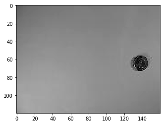

```python
plt.imshow(img_data[2070].reshape( 120, 160 ), cmap = plt.cm.gray)
```

### 2.3 Visulization

Define a plot gallary and show several images.

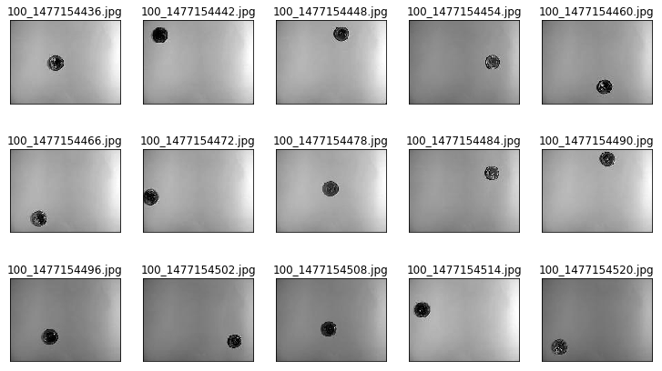

```python
# a helper plotting function
def plot_gallery(images, titles, h, w, n_row=3, n_col=5):
    """Helper function to plot a gallery of portraits"""
    plt.figure(figsize=(2 * n_col, 2 * n_row))
    plt.subplots_adjust(bottom=0, left=.01, right=.99, top=.90, hspace=.35)
    for i in range(n_row * n_col):
        plt.subplot(n_row, n_col, i + 1)
        plt.imshow(images[i].reshape((h, w)), cmap=plt.cm.gray)
        plt.title(titles[i], size=12)
        plt.xticks(())
        plt.yticks(())

labels =  [file_name_type[i] for i in range(size)]
plot_gallery(img_data, labels, 120, 160)
```

## 3.Data Reduction

### 3.1 Linear Dimensionality Reduction using PCA

#### 3.1.1 Full PCA

```python
from sklearn.decomposition import PCA
# fit a linear Principal Components Analysis model to the data
pca = PCA(n_components=500)
%time pca.fit(img_data)
```

```
Wall time: 8.18 s
```

```
PCA(copy=True, iterated_power='auto', n_components=500, random_state=None,
  svd_solver='auto', tol=0.0, whiten=False)
```

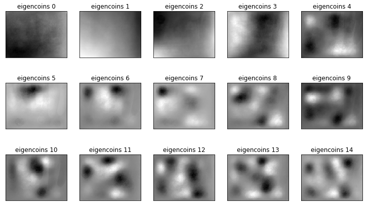

```python
eigencoins = pca.components_
eigenlabels = ['eigencoins ' + str(i) for i in range(size)]

plot_gallery(eigencoins, eigenlabels, 120, 160)
```

We can easily tell from the graphs that as the eigencoins increased, the eigenimages show more details.

```python
def plot_explained_variance(pca):
    import plotly.offline
    import plotly
    from plotly.graph_objs import Scatter, Marker, Layout, XAxis, YAxis, Bar, Line
    plotly.offline.init_notebook_mode(connected=True) # run at the start of every notebook

    explained_var = pca.explained_variance_ratio_
    cum_var_exp = np.cumsum(explained_var)

    plotly.offline.iplot({
        "data": [Bar(y=explained_var, name='individual explained variance'),
                 Scatter(y=cum_var_exp, name='cumulative explained variance')
            ],
        "layout": Layout(xaxis=XAxis(title='Principal components'), yaxis=YAxis(title='Explained variance ratio'))
    })
```

```python
plot_explained_variance(pca)
```

[interactive chart not shown]

According to the graph, 50 components explain 80% of total variences.136 components can explain 90% of total variation.And 500 components can explain almost 95% of total variance. So 500 dimentions are enough to be chosen for representing the images with high accuracy.

#### 3.1.2 Randomized PCA

```python
##Randomized PCA##
from sklearn.decomposition import RandomizedPCA

rpca = RandomizedPCA(n_components=500)
%time rpca.fit(img_data)
```

```
Wall time: 5.12 s
```

```
RandomizedPCA(copy=True, iterated_power=2, n_components=500,
       random_state=None, whiten=False)
```

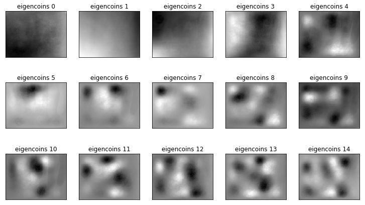

```python
r_eigencoins = rpca.components_
plot_gallery(r_eigencoins, eigenlabels, 120, 160)
```

```python
plot_explained_variance(rpca)
```

[interactive chart not shown]

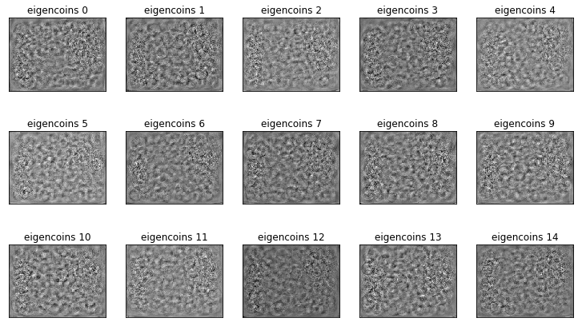

```python
plot_gallery(r_eigencoins - eigencoins, eigenlabels, 120, 160)
```

Same performance with full PCA. So 500 dimensions has been designed for our image process.

### 3.2 Non-linear Dimensionality Reduction using Kernal PCA

```python
##kernel##
from sklearn.decomposition import KernelPCA

kpca = KernelPCA(n_components=500, kernel='rbf',
                 gamma=10, fit_inverse_transform=True)
%time kpca.fit(img_data)
```

```
Wall time: 9.82 s
```

```
KernelPCA(alpha=1.0, coef0=1, copy_X=True, degree=3, eigen_solver='auto',
     fit_inverse_transform=True, gamma=10, kernel='rbf',
     kernel_params=None, max_iter=None, n_components=500, n_jobs=1,
     random_state=None, remove_zero_eig=False, tol=0)
```

### 3.3 Comparing PCA with Kernal PCA

```python
idx = np.random.choice(df.shape[0])
orig = df.iloc[idx]
np.shape(orig)
```

```
(19200,)
```

```python
idx = np.random.choice(df.shape[0])
def plot_reconstruction_comparison(data, idx, pca, rpca, kpca):
    orig = df.iloc[idx].values.reshape(1,-1)
    pca_restruct = pca.inverse_transform(pca.transform(orig))
    rpca_restruct = rpca.inverse_transform(rpca.transform(orig))
    kpca_restruct = kpca.inverse_transform(kpca.transform(orig))

    fig, ax = plt.subplots(nrows=2, ncols=2)

    ax[0][0].imshow(orig.reshape(120,160), cmap=plt.cm.gray)
    ax[0][0].set_title('Original Image')
    ax[0][0].set_xticks(())
    ax[0][0].set_yticks(())


    ax[0][1].imshow(pca_restruct.reshape(120,160), cmap=plt.cm.gray)
    ax[0][1].set_title('PCA Reconstruction')
    ax[0][1].set_xticks(())
    ax[0][1].set_yticks(())

    ax[1][0].imshow(rpca_restruct.reshape(120,160), cmap=plt.cm.gray)
    ax[1][0].set_title('RPCA Reconstruction')
    ax[1][0].set_xticks(())
    ax[1][0].set_yticks(())

    ax[1][1].imshow(kpca_restruct.reshape(120,160), cmap=plt.cm.gray)
    ax[1][1].set_title('KPCA Reconstruction')
    ax[1][1].set_xticks(())
    ax[1][1].set_yticks(())

    plt.tight_layout
```

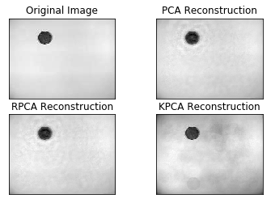

```python
ix = np.random.choice(range(img_data.shape[0]))
plot_reconstruction_comparison(img_data, idx,  pca, rpca, kpca)
```

The image for either PCA or KPCA are vague. It's really hard to tell which technique performs better. So we decide to run a two sample t-test for comparing.

Quantitative Analysis :

```python
##Run only once please##
##Quantitative Analysis##
import pickle
restruct_pca = pd.DataFrame(np.zeros(df.shape),
                            index=df.index,
                            columns=df.columns)

for i in range(df.shape[0]):
    if i%100==0:
        print(i)
    restruct_pca.iloc[i] = pca.inverse_transform(
        pca.transform(df.iloc[i].values.reshape(1,-1)))

pickle.dump(restruct_pca, open(os.path.join(os.pardir,
                                            'E:/CSE 7324/classification_dataset',
                                            'compressed_image',
                                            'restruct_pca.p'),
                               'wb'))

restruct_kpca = pd.DataFrame(np.zeros(df.shape),
                            index=df.index,
                            columns=df.columns)

for i in range(df.shape[0]):
    if i%100==0:
        print(i)
    restruct_kpca.iloc[i] = kpca.inverse_transform(
        kpca.transform(df.iloc[i].values.reshape(1,-1)))

pickle.dump(restruct_kpca, open(os.path.join(os.pardir,
                                             'E:/CSE 7324/classification_dataset',
                                             'compressed_image',
                                             'restruct_kcpa.p'), 'wb'))
```

[output not shown]

```python
restruct_pca.head(10)
```

|  | 0 | 1 | 2 | 3 | 4 | 5 | 6 | 7 | 8 | 9 | ... | 19190 | 19191 | 19192 | 19193 | 19194 | 19195 | 19196 | 19197 | 19198 | 19199 |
| --- | --- | --- | --- | --- | --- | --- | --- | --- | --- | --- | --- | --- | --- | --- | --- | --- | --- | --- | --- | --- | --- |
| 0 | 96.659681 | 92.684902 | 92.059459 | 95.545256 | 101.787682 | 102.551034 | 103.027109 | 101.429420 | 104.326283 | 105.012765 | ... | 148.477472 | 149.442407 | 150.130350 | 148.323958 | 147.458357 | 148.119360 | 147.397300 | 146.387783 | 144.413675 | 142.351686 |
| 1 | 94.208517 | 91.102031 | 90.610153 | 94.165901 | 96.088298 | 97.161771 | 97.476371 | 97.149031 | 99.431871 | 101.120508 | ... | 148.524368 | 148.939347 | 145.533379 | 143.990479 | 140.822112 | 137.798555 | 135.319078 | 134.427516 | 126.506778 | 116.233772 |
| 2 | 91.523835 | 87.779068 | 88.736734 | 91.665506 | 95.213024 | 97.804445 | 99.784722 | 101.546758 | 104.193505 | 104.439021 | ... | 148.729934 | 148.575510 | 144.797804 | 139.934340 | 134.612099 | 131.751907 | 130.258884 | 124.395662 | 110.810810 | 98.006226 |
| 3 | 79.041338 | 85.400068 | 89.930220 | 92.542710 | 91.842901 | 94.868543 | 96.740157 | 99.471947 | 102.201286 | 102.914598 | ... | 143.567832 | 145.292594 | 147.264434 | 146.022238 | 146.363191 | 145.354580 | 144.064668 | 140.928766 | 136.206900 | 132.692575 |
| 4 | 75.586330 | 83.721562 | 85.110674 | 88.368908 | 92.614802 | 94.236776 | 96.971623 | 97.276860 | 99.289855 | 99.289790 | ... | 133.514701 | 133.916565 | 137.062756 | 136.743940 | 138.278959 | 139.705951 | 138.761138 | 139.930287 | 136.909730 | 137.888590 |
| 5 | 87.145041 | 83.624696 | 85.105419 | 87.952478 | 89.509696 | 91.869759 | 94.429903 | 97.257116 | 99.442730 | 99.525398 | ... | 140.897000 | 141.091303 | 139.559834 | 140.719478 | 141.091960 | 140.623801 | 139.088635 | 137.930965 | 132.248867 | 127.221594 |
| 6 | 77.707940 | 82.342644 | 87.131154 | 89.480072 | 91.479051 | 94.998450 | 94.920179 | 95.785383 | 99.600622 | 99.752972 | ... | 137.659376 | 138.163957 | 137.757910 | 138.661760 | 138.818756 | 140.621964 | 141.916769 | 139.747529 | 137.341808 | 133.845470 |
| 7 | 103.593979 | 103.677286 | 109.080108 | 112.171942 | 113.325921 | 116.084089 | 117.523619 | 118.779188 | 123.070217 | 122.921777 | ... | 168.350639 | 168.818972 | 168.101673 | 166.897212 | 166.433393 | 166.913035 | 166.674669 | 165.621998 | 162.742678 | 162.292929 |
| 8 | 93.713225 | 106.607742 | 107.078962 | 106.584970 | 111.106564 | 112.446666 | 116.592598 | 117.795806 | 121.466402 | 120.680354 | ... | 158.919111 | 158.982109 | 164.250769 | 171.041842 | 174.767831 | 173.231230 | 171.408725 | 166.611718 | 159.346845 | 155.440852 |
| 9 | 99.775978 | 105.344423 | 111.085688 | 113.130432 | 112.067261 | 113.869336 | 116.565837 | 119.516168 | 122.419173 | 122.961689 | ... | 166.777355 | 167.145353 | 168.095126 | 170.680407 | 171.657118 | 170.650493 | 169.023788 | 165.299745 | 160.521433 | 155.688473 |

10 rows × 19200 columns

```python
restruct_kpca.head(10)
```

|  | 0 | 1 | 2 | 3 | 4 | 5 | 6 | 7 | 8 | 9 | ... | 19190 | 19191 | 19192 | 19193 | 19194 | 19195 | 19196 | 19197 | 19198 | 19199 |
| --- | --- | --- | --- | --- | --- | --- | --- | --- | --- | --- | --- | --- | --- | --- | --- | --- | --- | --- | --- | --- | --- |
| 0 | 81.621127 | 85.287681 | 88.821179 | 90.408082 | 92.118011 | 93.418254 | 95.525221 | 96.631332 | 100.627053 | 101.124484 | ... | 127.445201 | 127.344997 | 124.577304 | 123.094456 | 122.375349 | 121.957849 | 120.797777 | 119.705646 | 119.437300 | 119.085152 |
| 1 | 44.620466 | 45.080653 | 46.060080 | 47.564003 | 48.581659 | 49.075425 | 49.455250 | 49.459092 | 51.955102 | 51.842154 | ... | 73.209239 | 73.713256 | 71.229733 | 74.729627 | 73.543631 | 71.094339 | 75.197108 | 76.508871 | 61.505927 | 41.115980 |
| 2 | 57.869415 | 58.377545 | 60.764026 | 62.032614 | 63.717695 | 65.085640 | 65.936548 | 65.958005 | 68.536700 | 68.361840 | ... | 95.899287 | 95.741178 | 98.375836 | 95.011413 | 90.360658 | 92.298730 | 100.662911 | 96.439457 | 62.717419 | 25.323141 |
| 3 | 43.518814 | 43.977725 | 45.449677 | 46.483257 | 47.986170 | 48.995048 | 49.494996 | 49.504775 | 51.499604 | 51.508418 | ... | 70.477846 | 70.986845 | 71.028106 | 71.537347 | 71.547999 | 71.546399 | 71.015235 | 70.491923 | 69.993587 | 69.478503 |
| 4 | 63.408338 | 64.072119 | 66.872211 | 69.319311 | 70.452863 | 72.391490 | 74.414359 | 75.722675 | 77.941505 | 77.935033 | ... | 100.639182 | 100.567570 | 100.120860 | 100.040860 | 100.368495 | 100.406298 | 100.037457 | 99.624589 | 97.621242 | 95.986287 |
| 5 | 44.836996 | 46.641814 | 48.320764 | 49.369030 | 49.978722 | 50.597861 | 52.210713 | 52.813875 | 54.522007 | 54.544251 | ... | 77.232996 | 77.241250 | 75.636340 | 75.705589 | 75.806439 | 75.683422 | 74.839308 | 74.085521 | 73.082702 | 72.515382 |
| 6 | 79.395150 | 82.205843 | 84.877339 | 87.566867 | 89.544925 | 91.940759 | 93.542993 | 94.910720 | 98.841909 | 99.189598 | ... | 127.285475 | 127.614207 | 125.818004 | 127.714794 | 128.339766 | 126.538439 | 121.943725 | 117.704446 | 116.213559 | 115.300644 |
| 7 | 61.264545 | 61.367506 | 62.600644 | 64.030807 | 65.765747 | 66.896110 | 67.342307 | 67.311857 | 70.101292 | 70.182672 | ... | 94.798255 | 94.845483 | 94.471636 | 95.109534 | 94.990409 | 94.748989 | 94.099503 | 93.545879 | 93.116307 | 92.686598 |
| 8 | 62.570597 | 64.128491 | 66.779304 | 68.192748 | 69.093913 | 69.899051 | 71.593328 | 72.369264 | 75.351895 | 75.406615 | ... | 98.240598 | 98.352700 | 98.035282 | 98.024902 | 97.742510 | 97.485570 | 96.694010 | 95.617338 | 95.077555 | 94.453727 |
| 9 | 88.869776 | 90.071998 | 92.472524 | 94.495140 | 95.885938 | 97.284941 | 99.209543 | 100.379418 | 102.951660 | 102.857616 | ... | 130.538921 | 130.485318 | 129.803434 | 130.412099 | 130.442770 | 130.024702 | 128.304957 | 126.150650 | 124.110029 | 123.075323 |

10 rows × 19200 columns

```python
import skimage
print(skimage.__version__)
```

```
0.13.1
```

```python
##Transfer dataframe to Vector
from skimage.measure import compare_ssim as ssim
def struction_sim(data1, data2):#, idx1, idx2):
    return ssim(data1, data2)

def get_sim_vec(data1, data2):
    vec_sim = pd.Series(np.zeros(df.shape[0]),
                        index=df.index)

    for i in range(data1.shape[0]):
        vec_sim[i] = struction_sim(data1[i], data2[i])

    return vec_sim
```

```python
##Define two vectors##
%time pca_vec = get_sim_vec(df, restruct_pca)
%time kpca_vec = get_sim_vec(df, restruct_kpca)
```

```
Wall time: 2.91 s
Wall time: 2.61 s
```

```python
#Paired two sample t-test##
from scipy.stats import ttest_rel
t, p = ttest_rel(pca_vec, kpca_vec)
print(p)
```

```
0.0
```

The null hypotheis is that PCA and KPCA are showing same performance. And the p value less than 0.05. That give us a result that these two methods are not performance as well as each other.

```python
print('PCA Scores:\n',
      pca_vec.head(20),
      '\n------------------\n',
      'KPCA Scores:\n',
      kpca_vec.head(20),
      '\n------------------\n')
```

```
PCA Scores:
 0     0.567310
1     0.677719
2     0.671438
3     0.684015
4     0.692146
5     0.717613
6     0.759474
7     0.741306
8     0.796921
9     0.800725
10    0.790669
11    0.780208
12    0.762919
13    0.742575
```

[output cut: 31 more lines]

We use SSIM index---structural similarity index instead of MSE to compare two methods. From the scores above, we can easily tell that PCA performance better in overall. Since the scores for PCA is higher that the scores for KPCA and that means PCA can capture more percisely in image process.

### 3.4 Feature Extraction with Daisy

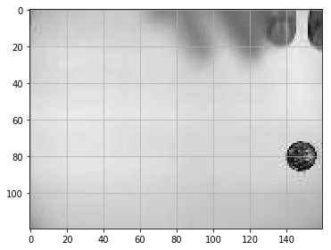

```python
X=df
from skimage.io import imshow

idx_to_reconstruct = int(np.random.rand(1)*len(X))
img  = img_data[idx_to_reconstruct].reshape((120,160))
img = (img/img.max())
imshow(img)
plt.grid()
```

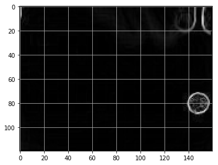

```python
from skimage.filters import sobel_h, sobel_v

gradient_mag = np.sqrt(sobel_v(img)**2 + sobel_h(img)**2 )
imshow(gradient_mag)
plt.grid()
```

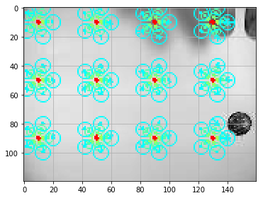

```python
from skimage.feature import daisy

# lets first visualize what the daisy descripto looks like
features, img_desc = daisy(img,step=40, radius=10, rings=3, histograms=5, orientations=8, visualize=True)
imshow(img_desc)
plt.grid()
```

```python
features = daisy(img,step=10, radius=10, rings=2, histograms=4, orientations=8, visualize=False)
print(features.shape)
print(features.shape[0]*features.shape[1]*features.shape[2])
```

```
(10, 14, 72)
10080
```

### 3.5 Visualize the Differences

```python
def apply_daisy(row,shape):
    feat = daisy(row.reshape(shape),step=10, radius=10, rings=2, histograms=6, orientations=8, visualize=False)
    return feat.reshape((-1))
%time test_feature = apply_daisy(img_data[3],(120,160))
test_feature.shape
```

```
Wall time: 29 ms
```

```
(14560,)
```

```python
0.027 * len(img_data)
```

```
82.593
```

```python
%time daisy_features = np.apply_along_axis(apply_daisy, 1, img_data, (120,160))
print(daisy_features.shape)
```

```
Wall time: 1min 9s
(3059, 14560)
```

```python
from sklearn.metrics.pairwise import pairwise_distances
# find the pairwise distance between all the different image features
%time dist_matrix = pairwise_distances(daisy_features)
```

```
Wall time: 1.34 s
```

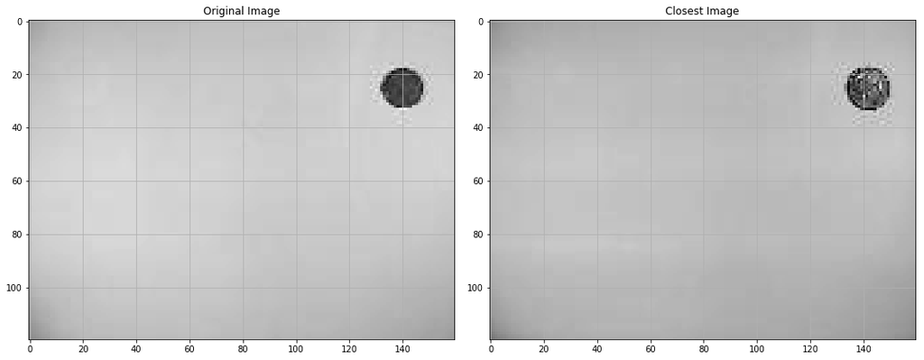

```python
import warnings
warnings.simplefilter('ignore')
import copy
# find closest image to current image
idx1 = 999
distances = copy.deepcopy(dist_matrix[idx1,:])
distances[idx1] = np.infty # dont pick the same image!
idx2 = np.argmin(distances)

plt.figure(figsize=(15,10))
plt.subplot(1,2,1)
imgsimilar1 = img_data[idx1].reshape((120,160))
imgsimilar1 = imgsimilar1/(imgsimilar1.max())
imshow(imgsimilar1)
plt.title("Original Image")
plt.grid()

plt.subplot(1,2,2)
imgsimilar2 = img_data[idx2].reshape((120,160))
imgsimilar2 = imgsimilar2/(imgsimilar2.max())
imshow(imgsimilar2)
plt.title("Closest Image")
plt.grid()
```

```python
X=df
n_samples, n_features = X.shape
print(n_samples)
```

```
3059
```

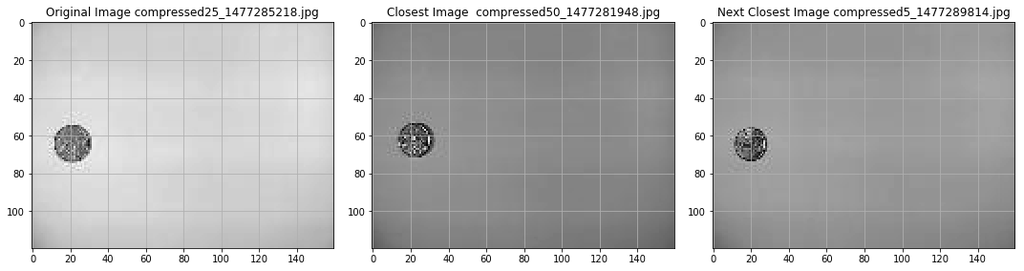

```
<function __main__.closest_image(dmat, idx1)>
```

```python
from ipywidgets import fixed
X=df
n_samples, n_features = X.shape
import warnings
warnings.simplefilter('ignore')
from ipywidgets import widgets
# put it together inside a nice widget
def closest_image(dmat,idx1):
    distances = copy.deepcopy(dmat[idx1,:]) # get all image diatances
    distances[idx1] = np.infty # dont pick the same image!
    idx2 = np.argmin(distances)

    distances[idx2] = np.infty
    idx3 = np.argmin(distances)

    plt.figure(figsize=(15,15))
    plt.subplot(1,3,1)
    imshow(img_data[idx1].reshape((120,160))/img_data[idx1].reshape((120,160)).max())
    plt.title("Original Image "+file_name_typenew[idx1])
    plt.grid()

    plt.subplot(1,3,2)
    imshow(img_data[idx2].reshape((120,160))/img_data[idx2].reshape((120,160)).max())
    plt.title("Closest Image  "+file_name_typenew[idx2])
    plt.grid()

    plt.subplot(1,3,3)
    imshow(img_data[idx3].reshape((120,160))/img_data[idx3].reshape((120,160)).max())
    plt.title("Next Closest Image "+file_name_typenew[idx3])
    plt.grid()

widgets.interact(closest_image,idx1=(0,n_samples-1,1),dmat=fixed(dist_matrix),__manual=True)
```

From the result we have above, the DAISY tenique is not fit for our model. Since the method match 50 cenvatos and 5 cenvatos for 25 cenvatos.

## 4. Exceptional Work

At this point, we do relize that there is a lot of blank in our images and some of them with notable difference in illumination. We think those images may contain some information that can cause bias of our result. So we decide to detect the coins and crop it out with cv2.findcountours.

```python
cropimg_path = "E:/CSE 7324/classification_dataset/crop_image"
```

```python
import cv2
for i in range(size):
    if i%100==0:
        print(i)
    image = cv2.imread(os.path.join(mypath + '/' + file_name_type[i]),1)
    if os.path.getsize(os.path.join(mypath + '/' + file_name_type[i]))!=0:
        gray=cv2.cvtColor(image,cv2.COLOR_BGR2GRAY)
        edged = cv2.Canny(image, 10, 250)
        x = cv2.findContours(edged.copy(), cv2.RETR_EXTERNAL, cv2.CHAIN_APPROX_SIMPLE)
        _a, cnts, _b = x

        idx = 0
        for c in cnts:
            x,y,w,h = cv2.boundingRect(c)
            if w>50 and h>50:
                idx+=1
                new_img=image[y:y+h,x:x+w]
                cv2.imwrite(os.path.join(cropimg_path + '/' + 'crop' + file_name_type[i]), new_img)
    else:
        continue
```

```
0
100
200
300
400
500
600
700
800
900
1000
1100
1200
1300
1400
1500
1600
1700
1800
1900
2000
2100
2200
2300
2400
2500
2600
2700
2800
2900
3000
```

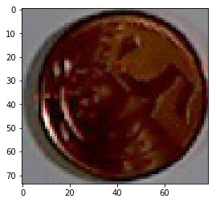

```python
img=mpimg.imread('E:/CSE 7324/classification_dataset/crop_image/crop5_1477145442.jpg')
imgplot = plt.imshow(img)
plt.show()
```

Now those images are ready to go through the previous feature extraction methods. However, another feature extraction technique upon the images can solve this problem without crop out the coins.

## 4.1 Introduction

### 4.1.1 What is SIFT?

The scale-invariant feature transform (SIFT) is a feature detection algorithm in computer vision to detect and describe local features in images. The algorithm was proposed by David Lowe in 1999 for the detection of local features in a digital image. It extracts features often called SIFT key points from the image in a circular region with an orientation. The SIFT detects key points from the image structures at multiple scales and rotation positions. Also the SIFT selected key points are invariant to translation, rotations, and rescaling of the image.

### 4.1.2 Why We Use It?

The heart of the coin sorting is feature selection and extraction mechanism. In general, coins are recognized from several different perspectives such as color, size or shape. The images we obtained may or may not give computer system an easy work for object recognition. Fortunately, using the Scale Invariant Feature Transform algorithm to handle the issues of rotations, scaling and illumination in a digital image is a wise choice. Those advantages are perfect match our needs as well as our dataset. Those images we used contains a lot of blank and some of them with notable difference in illumination. Using SIFT technique, the following challenges can be solved: 1. The noise in images due to different illumination condition. 2. Coins have stains, hole, or scratch on the surface area. 3. Coins are not always in the same spot of the images.

### 4.1.3 How does it work?

```python
 #coding: utf-8
from matplotlib import pyplot as plt
from imagedt.decorator import time_cost
import cv2
print ('cv version: ', cv2.__version__)


def bgr_rgb(img):
    (r, g, b) = cv2.split(img)
    return cv2.merge([b, g, r])


def orb_detect(image_a, image_b):
    # feature match
    orb = cv2.ORB_create()

    kp1, des1 = orb.detectAndCompute(image_a, None)
    kp2, des2 = orb.detectAndCompute(image_b, None)

    # create BFMatcher object
    bf = cv2.BFMatcher(cv2.NORM_HAMMING, crossCheck=True)

    # Match descriptors.
    matches = bf.match(des1, des2)

    # Sort them in the order of their distance.
    matches = sorted(matches, key=lambda x: x.distance)

    # Draw first 10 matches.
    img3 = cv2.drawMatches(image_a, kp1, image_b, kp2, matches[:100], None, flags=2)

    return bgr_rgb(img3)

@time_cost
def sift_detect(img1, img2, detector='surf'):
    if detector.startswith('si'):
        print ("sift detector......")
        sift = cv2.xfeatures2d.SURF_create()
    else:
        print ("surf detector......")
        sift = cv2.xfeatures2d.SURF_create()

    # find the keypoints and descriptors with SIFT
    kp1, des1 = sift.detectAndCompute(img1, None)
    kp2, des2 = sift.detectAndCompute(img2, None)

    # BFMatcher with default params
    bf = cv2.BFMatcher()
    matches = bf.knnMatch(des1, des2, k=2)

    # Apply ratio test
    good = [[m] for m, n in matches if m.distance < 0.5 * n.distance]

    # cv2.drawMatchesKnn expects list of lists as matches.
    img3 = cv2.drawMatchesKnn(img1, kp1, img2, kp2, good, None, flags=2)

    return bgr_rgb(img3)


if __name__ == "__main__":
    # load image
    image_a = cv2.imread('E:/CSE 7324/classification_dataset/all/5_1477145544.jpg')
    image_b = cv2.imread('E:/CSE 7324/classification_dataset/all/5_1477145550.jpg')

    # ORB
    # img = orb_detect(image_a, image_b)

    # SIFT or SURF
    img = sift_detect(image_a, image_b)

    plt.imshow(img)
    plt.show()
```

[output not shown]

# Reference

https://www.quora.com/How-can-I-detect-an-object-from-static-image-and-crop-it-from-the-image-using-openCV

https://docs.opencv.org/3.0-beta/doc/py_tutorials/py_feature2d/py_sift_intro/py_sift_intro.html

https://en.wikipedia.org/wiki/Scale-invariant_feature_transform

https://www.cnblogs.com/python-life/articles/8727692.html